# Assignment 4 - (Tree-based Methods) Data Mining and Statistical Learning

Ziwen Zhang

2023-07-10

## Dataset

Use the “Heart” dataset saved in the module that contains a binary outcome AHD for 303 patients who presented with chest pain. An outcome value of Yes indicates the presence of heart disease based on an angiographic test, while No means no heart disease. There are 13 predictors including Age, Sex, Chol (a cholesterol measurement), and other heart and lung function measurements.

```r
# load the data set
heart <- read.csv("heart.csv")[,-1]

# view data type
str(heart)
```

```
## 'data.frame':    303 obs. of  14 variables:
##  $ Age      : int  63 67 67 37 41 56 62 57 63 53 ...
##  $ Sex      : int  1 1 1 1 0 1 0 0 1 1 ...
##  $ ChestPain: chr  "typical" "asymptomatic" "asymptomatic" "nonanginal" ...
##  $ RestBP   : int  145 160 120 130 130 120 140 120 130 140 ...
##  $ Chol     : int  233 286 229 250 204 236 268 354 254 203 ...
##  $ Fbs      : int  1 0 0 0 0 0 0 0 0 1 ...
##  $ RestECG  : int  2 2 2 0 2 0 2 0 2 2 ...
##  $ MaxHR    : int  150 108 129 187 172 178 160 163 147 155 ...
##  $ ExAng    : int  0 1 1 0 0 0 0 1 0 1 ...
##  $ Oldpeak  : num  2.3 1.5 2.6 3.5 1.4 0.8 3.6 0.6 1.4 3.1 ...
##  $ Slope    : int  3 2 2 3 1 1 3 1 2 3 ...
##  $ Ca       : int  0 3 2 0 0 0 2 0 1 0 ...
##  $ Thal     : chr  "fixed" "normal" "reversable" "normal" ...
##  $ AHD      : chr  "No" "Yes" "Yes" "No" ...
```

```r
# change datatype into factor
heart$Thal <- as.factor(heart$Thal)
heart$AHD <- as.factor(heart$AHD)
heart$ChestPain <- as.factor(heart$ChestPain)

# load libraries
library(tidyverse)
library(tree)
library(randomForest)
library(gbm)
```

## Question

With the data set, fit the following tree-based predictive model -

### Question (1) CART Model

A single classification and regression tree that has been pruned back adequately. Explain in details the steps taken to prune the tree.

```r
# impute the missing data
heart_imputed <- rfImpute(AHD ~ .-AHD, data = heart)
```

```
## ntree      OOB      1      2
##   300:  16.50% 11.59% 22.30%
## ntree      OOB      1      2
##   300:  16.83% 12.20% 22.30%
## ntree      OOB      1      2
##   300:  17.49% 12.80% 23.02%
## ntree      OOB      1      2
##   300:  16.17% 10.98% 22.30%
## ntree      OOB      1      2
##   300:  17.49% 12.20% 23.74%
```

```r
set.seed(24543)
# divide data into testing and training 50%
test_index <- sample(nrow(heart_imputed), ceiling(0.5*nrow(heart_imputed)))
test_heart <- heart_imputed[test_index, -1] # eliminate the target
train_heart <- heart_imputed[-test_index, ]

test_label <- as.numeric(heart_imputed[test_index, 1]) # set as target
test_full <- heart_imputed[test_index, ]
```

#### fit a classification tree

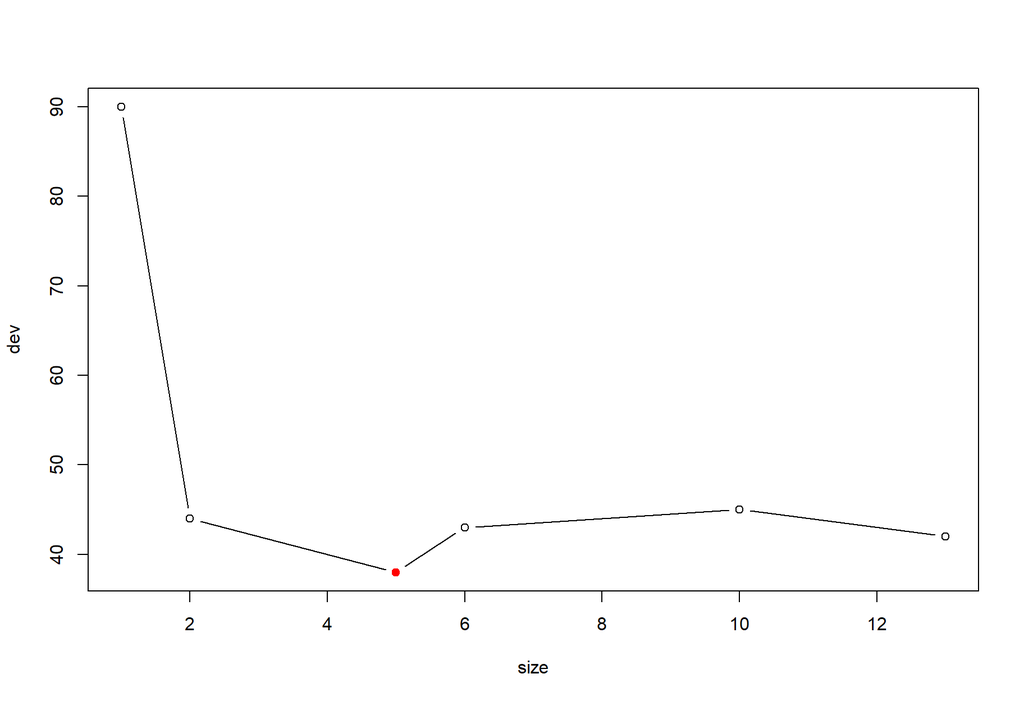

```r
set.seed(765)
# build a single classification and regression tree
tree_model <- tree(AHD ~.-AHD, data=train_heart, method="gini")
tree_model.cv <- cv.tree(tree_model, FUN=prune.misclass, K=10)

# plot the error as a function of the tree size
plot(dev ~ size, data=as.data.frame(tree_model.cv[1:3]), type="b")
points(x=tree_model.cv$size[tree_model.cv$dev==min(tree_model.cv$dev)],
y=rep(min(tree_model.cv$dev),sum(tree_model.cv$dev==min(tree_model.cv$dev))),col="red",pch=19)
```

From the plot, we can see that the red point demonstrates the tree size with the smallest error.